# 1. PLOT BASIC LINE PLOT

```python
from jupyterthemes import jtplot
jtplot.style(theme = 'monokai', context = 'notebook', ticks = True, grid = False)
# setting the style of the notebook to be monokai theme
# this line of code is important to ensure that we are able to see the x and y axes clearly
# If you don't run this code line, you will notice that the xlabel and ylabel on any plot is black on black and it will be hard to see them.
```

```python
import numpy as np
import matplotlib.pyplot as plt
import pandas as pd
```

```python
# Read the stock prices data using pandas
stock_df = pd.read_csv('stock_data.csv')
stock_df
```

|  | Date | FB | TWTR | NFLX |
| --- | --- | --- | --- | --- |
| 0 | 2013-11-07 | 47.560001 | 44.900002 | 46.694286 |
| 1 | 2013-11-08 | 47.529999 | 41.650002 | 47.842857 |
| 2 | 2013-11-11 | 46.200001 | 42.900002 | 48.272858 |
| 3 | 2013-11-12 | 46.610001 | 41.900002 | 47.675713 |
| 4 | 2013-11-13 | 48.709999 | 42.599998 | 47.897144 |
| ... | ... | ... | ... | ... |
| 1707 | 2020-08-20 | 269.010010 | 38.959999 | 497.899994 |
| 1708 | 2020-08-21 | 267.010010 | 39.259998 | 492.309998 |
| 1709 | 2020-08-24 | 271.390015 | 40.490002 | 488.809998 |
| 1710 | 2020-08-25 | 280.820007 | 40.549999 | 490.579987 |
| 1711 | 2020-08-26 | 303.910004 | 41.080002 | 547.530029 |

1712 rows × 4 columns

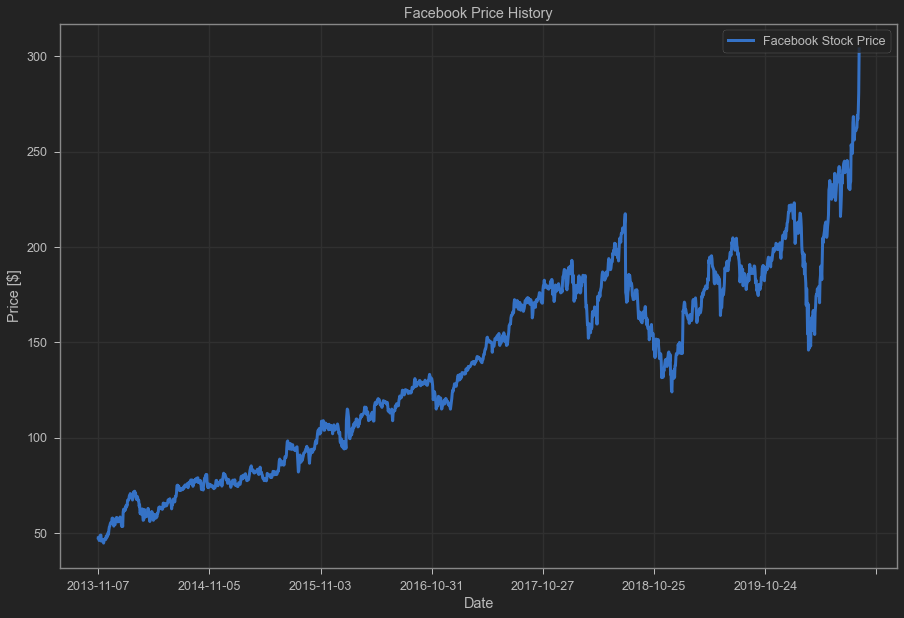

```python
#
stock_df.plot(x ='Date', y ='FB', label = 'Facebook Stock Price', figsize = (15, 10), linewidth = 3)
plt.ylabel('Price [$]')
plt.title('Facebook Price History')
plt.legend(loc = 'upper right')
plt.grid()
```

MINI CHALLLENGE #1:

- Plot similar kind of graph for NFLX
- Change the line color to red and increase the line width

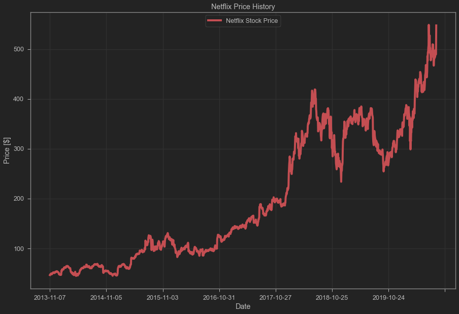

```python
stock_df.plot(x ='Date', y = 'NFLX', label = 'Netflix Stock Price', figsize = (15,10),
              linewidth = 4, color = 'r')
plt.ylabel('Price [$]')
plt.title('Netflix Price History')
plt.legend(loc = 'upper center')
plt.grid()
```

# 2. PLOT SCATTERPLOT

```python
# Read daily return data using pandas
daily_return_df = pd.read_csv('stocks_daily_returns.csv')
daily_return_df
```

|  | Date | FB | TWTR | NFLX |
| --- | --- | --- | --- | --- |
| 0 | 2013-11-07 | 0.000000 | 0.000000 | 0.000000 |
| 1 | 2013-11-08 | -0.063082 | -7.238307 | 2.459768 |
| 2 | 2013-11-11 | -2.798229 | 3.001200 | 0.898778 |
| 3 | 2013-11-12 | 0.887446 | -2.331002 | -1.237020 |
| 4 | 2013-11-13 | 4.505467 | 1.670635 | 0.464452 |
| ... | ... | ... | ... | ... |
| 1707 | 2020-08-20 | 2.444881 | 0.179995 | 2.759374 |
| 1708 | 2020-08-21 | -0.743467 | 0.770018 | -1.122715 |
| 1709 | 2020-08-24 | 1.640390 | 3.132970 | -0.710934 |
| 1710 | 2020-08-25 | 3.474701 | 0.148177 | 0.362102 |
| 1711 | 2020-08-26 | 8.222348 | 1.307036 | 11.608717 |

1712 rows × 4 columns

```python
X = daily_return_df['FB']
X
```

```
0       0.000000
1      -0.063082
2      -2.798229
3       0.887446
4       4.505467
          ...
1707    2.444881
1708   -0.743467
1709    1.640390
1710    3.474701
1711    8.222348
Name: FB, Length: 1712, dtype: float64
```

```python
Y = daily_return_df['TWTR']
Y
```

```
0       0.000000
1      -7.238307
2       3.001200
3      -2.331002
4       1.670635
          ...
1707    0.179995
1708    0.770018
1709    3.132970
1710    0.148177
1711    1.307036
Name: TWTR, Length: 1712, dtype: float64
```

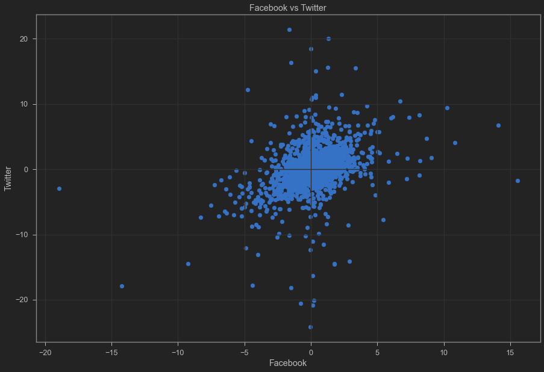

```python
plt.figure(figsize = (15, 10))
plt.scatter(X, Y)
plt.title('Facebook vs Twitter')
plt.xlabel('Facebook')
plt.ylabel('Twitter')
plt.grid()
```

MINI CHALLLENGE #2:

- Plot similar kind of graph for Facebook and Netflix

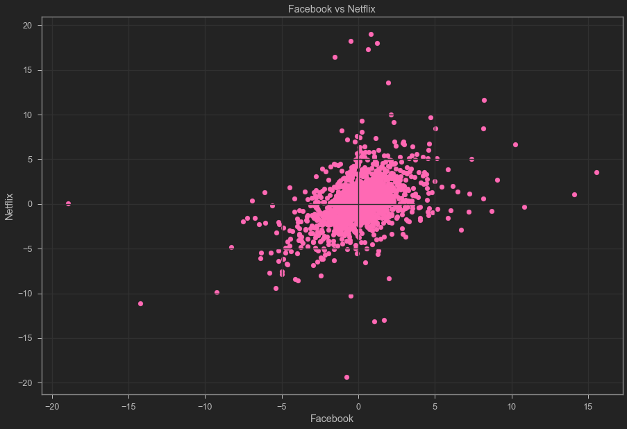

```python
X = daily_return_df['FB']
Y = daily_return_df['NFLX']
plt.figure(figsize = (15, 10))
plt.scatter(X, Y, color = 'hotpink')
plt.title('Facebook vs Netflix')
plt.xlabel('Facebook')
plt.ylabel('Netflix')
plt.grid()
```

# 3. PLOT PIE CHART

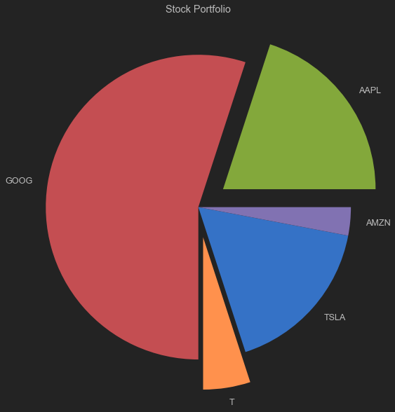

```python
values = [20, 55, 5, 17, 3]
colors = ['g', 'r', 'y', 'b', 'm']
labels = ['AAPL', 'GOOG', 'T', 'TSLA', 'AMZN']
explode = [0.2, 0, 0.2, 0, 0]
# Use matplotlib to plot a pie chart
plt.figure(figsize = (10, 10))
plt.pie(values, colors = colors, labels = labels, explode = explode)
plt.title('Stock Portfolio')
```

MINI CHALLENGE #3:

- Plot the pie chart for the same stocks assuming equal allocation
- Explode Amazon and Google slices

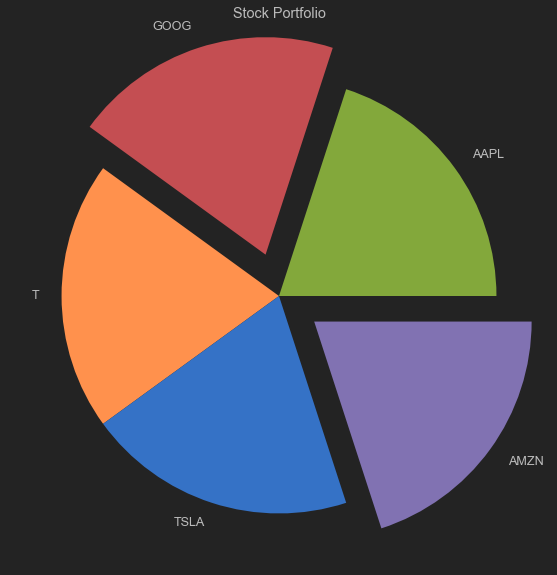

```python
values = [20, 20, 20, 20, 20]
colors = ['g', 'r', 'y', 'b', 'm']
labels = ['AAPL', 'GOOG', 'T', 'TSLA', 'AMZN']
explode = [0, 0.2, 0., 0, 0.2]
# Use matplotlib to plot a pie chart
plt.figure(figsize = (10, 10))
plt.pie(values, colors = colors, labels = labels, explode = explode)
plt.title('Stock Portfolio')
```

# 4. PLOT HISTOGRAMS

```python
daily_return_df
```

|  | Date | FB | TWTR | NFLX |
| --- | --- | --- | --- | --- |
| 0 | 2013-11-07 | 0.000000 | 0.000000 | 0.000000 |
| 1 | 2013-11-08 | -0.063082 | -7.238307 | 2.459768 |
| 2 | 2013-11-11 | -2.798229 | 3.001200 | 0.898778 |
| 3 | 2013-11-12 | 0.887446 | -2.331002 | -1.237020 |
| 4 | 2013-11-13 | 4.505467 | 1.670635 | 0.464452 |
| ... | ... | ... | ... | ... |
| 1707 | 2020-08-20 | 2.444881 | 0.179995 | 2.759374 |
| 1708 | 2020-08-21 | -0.743467 | 0.770018 | -1.122715 |
| 1709 | 2020-08-24 | 1.640390 | 3.132970 | -0.710934 |
| 1710 | 2020-08-25 | 3.474701 | 0.148177 | 0.362102 |
| 1711 | 2020-08-26 | 8.222348 | 1.307036 | 11.608717 |

1712 rows × 4 columns

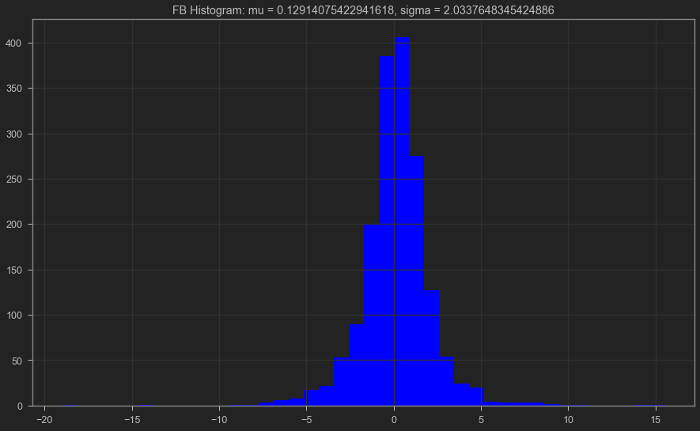

```python
# A histogram represents data using bars of various heights.
# Each bar groups numbers into specific ranges.
# Taller bars show that more data falls within that specific range.
mu = daily_return_df['FB'].mean()
sigma = daily_return_df['FB'].std()
num_bins = 40
plt.figure(figsize = (15, 9))
plt.hist(daily_return_df['FB'], num_bins, facecolor = 'blue');
# semicolon removes text preceding histogram
plt.grid()
plt.title('FB Histogram: mu = ' + str(mu) + ', sigma = ' + str(sigma))
```

MINI CHALLENGE #4:

- Plot the histogram for TWITTER returns using 30 bins

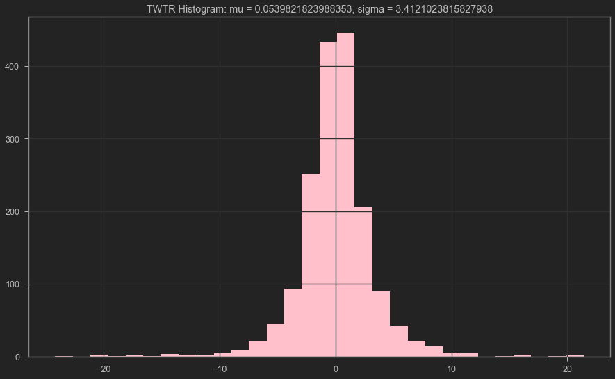

```python
mu = daily_return_df['TWTR'].mean()
sigma = daily_return_df['TWTR'].std()
num_bins = 30
plt.figure(figsize = (15, 9))
plt.hist(daily_return_df['TWTR'], num_bins, facecolor = 'pink');
# semicolon removes text preceding histogram
plt.grid()
plt.title('TWTR Histogram: mu = ' + str(mu) + ', sigma = ' + str(sigma))
```

# 5. PLOT MULTIPLE PLOTS

```python
stock_df
```

|  | Date | FB | TWTR | NFLX |
| --- | --- | --- | --- | --- |
| 0 | 2013-11-07 | 47.560001 | 44.900002 | 46.694286 |
| 1 | 2013-11-08 | 47.529999 | 41.650002 | 47.842857 |
| 2 | 2013-11-11 | 46.200001 | 42.900002 | 48.272858 |
| 3 | 2013-11-12 | 46.610001 | 41.900002 | 47.675713 |
| 4 | 2013-11-13 | 48.709999 | 42.599998 | 47.897144 |
| ... | ... | ... | ... | ... |
| 1707 | 2020-08-20 | 269.010010 | 38.959999 | 497.899994 |
| 1708 | 2020-08-21 | 267.010010 | 39.259998 | 492.309998 |
| 1709 | 2020-08-24 | 271.390015 | 40.490002 | 488.809998 |
| 1710 | 2020-08-25 | 280.820007 | 40.549999 | 490.579987 |
| 1711 | 2020-08-26 | 303.910004 | 41.080002 | 547.530029 |

1712 rows × 4 columns

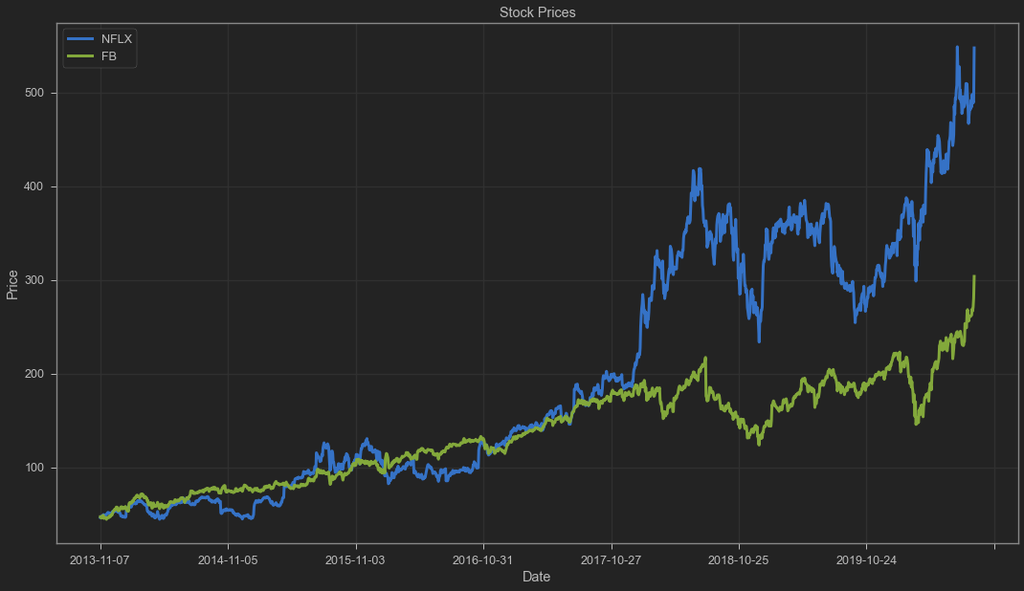

```python
stock_df.plot(x = 'Date', y = ['NFLX', 'FB'], figsize = (18, 10), linewidth = 3)
plt.ylabel('Price')
plt.title('Stock Prices')
plt.grid()
```

MINI CHALLLENGE #5:

- Plot a similar graph containing prices of Netflix, Twitter and Facebook
- Add legend indicating all the stocks
- Place the legend in the "upper center" location

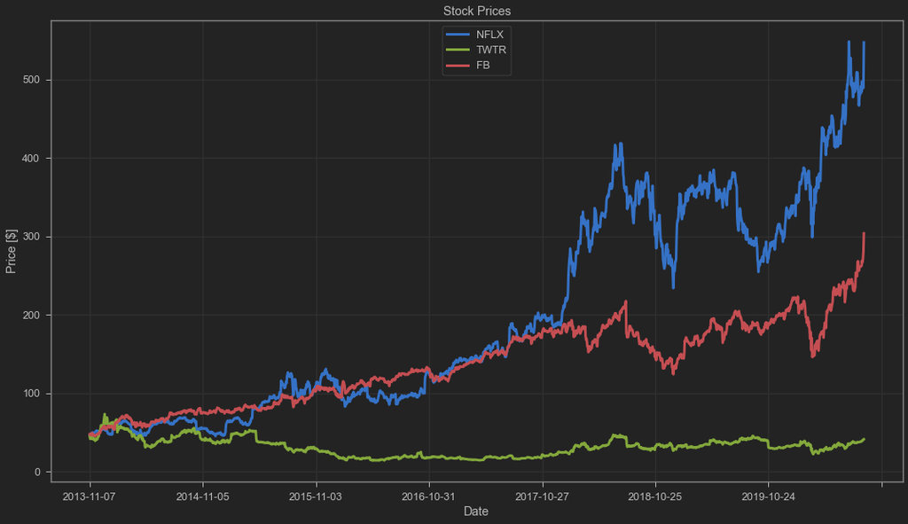

```python
stock_df.plot(x = 'Date', y = ['NFLX', 'TWTR', 'FB'], figsize = (18, 10), linewidth = 3)
plt.ylabel('Price [$]')
plt.legend(loc = 'upper center')
plt.title('Stock Prices')
plt.grid()
```

# 6. PLOT SUBPLOTS

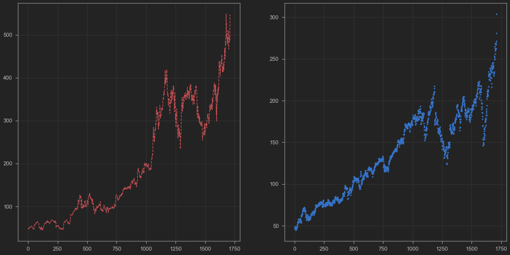

```python
plt.figure(figsize = (20,10))
plt.subplot(1,2, 1)
# 1 row, 2 columns, first plot to configure
plt.plot(stock_df['NFLX'], 'r--')
plt.grid()

plt.subplot(1,2, 2)
plt.plot(stock_df['FB'], 'b.')
plt.grid()
```

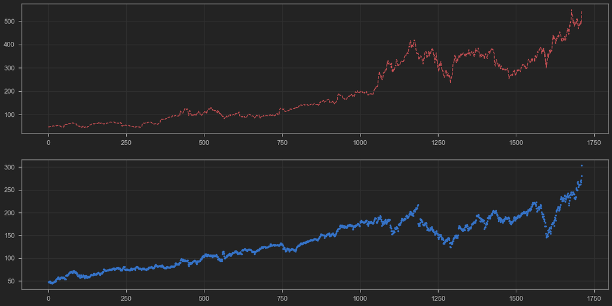

```python
plt.figure(figsize = (20,10))
plt.subplot(2,1, 1)
# 1 row, 2 columns, first plot to configure
plt.plot(stock_df['NFLX'], 'r--')
plt.grid()

plt.subplot(2,1, 2)
plt.plot(stock_df['FB'], 'b.')
plt.grid()
```

MINI CHALLLENGE #6:

- Create subplots like above for Twitter, Facebook and Netflix

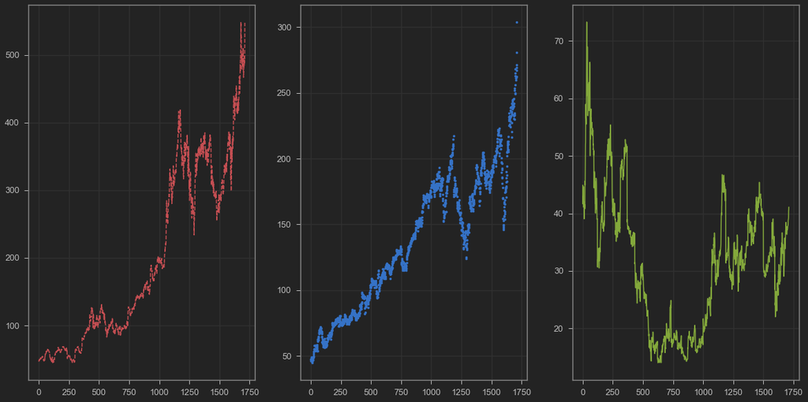

```python
plt.figure(figsize = (20,10))
plt.subplot(1, 3, 1)
# 1 row, 2 columns, first plot to configure
plt.plot(stock_df['NFLX'], 'r--')
plt.grid()

plt.subplot(1, 3, 2)
plt.plot(stock_df['FB'], 'b.')
plt.grid()

plt.subplot(1, 3, 3)
plt.plot(stock_df['TWTR'], 'g')
plt.grid()
```

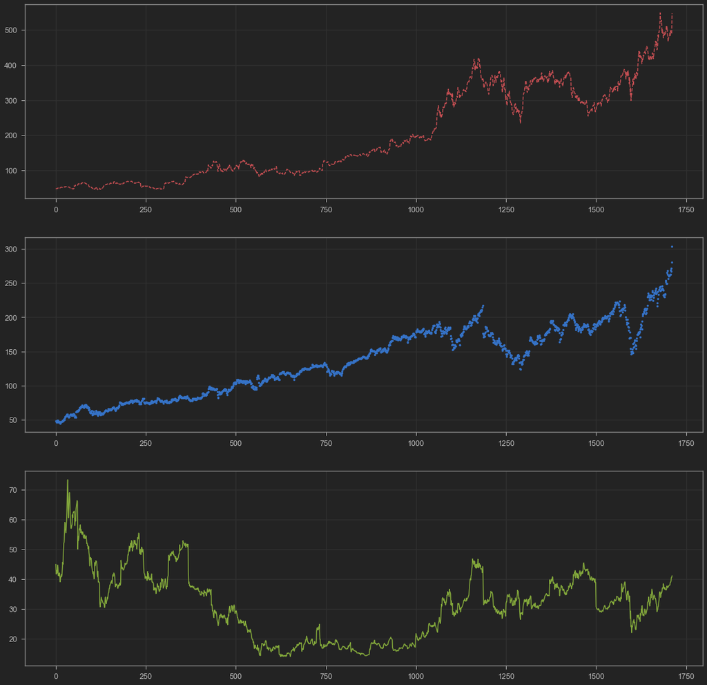

```python
plt.figure(figsize = (20,20))
plt.subplot(3, 1, 1)
# 1 row, 2 columns, first plot to configure
plt.plot(stock_df['NFLX'], 'r--')
plt.grid()

plt.subplot(3, 1, 2)
plt.plot(stock_df['FB'], 'b.')
plt.grid()

plt.subplot(3, 1, 3)
plt.plot(stock_df['TWTR'], 'g')
plt.grid()
```

# 7. PLOT 3D PLOTS

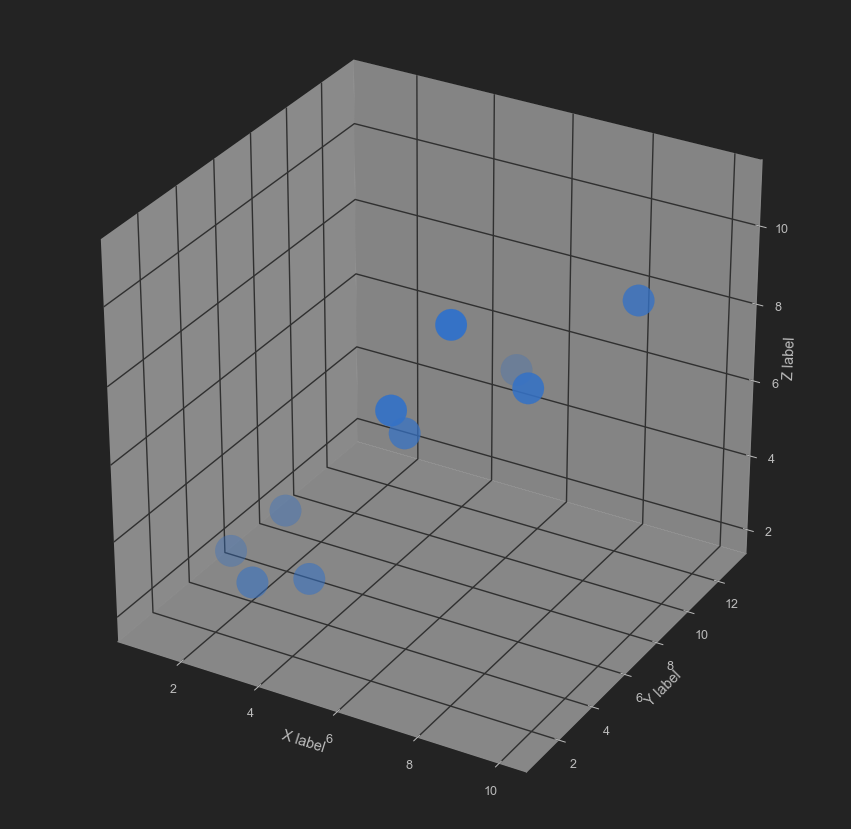

```python
# Toolkits are collections of application-specific functions that extend Matplotlib.
# mpl_toolkits.mplot3d provides tools for basic 3D plotting.
# https://matplotlib.org/mpl_toolkits/index.html

from mpl_toolkits.mplot3d import Axes3D

fig = plt.figure(figsize = (15, 15))
ax = fig.add_subplot(111, projection = '3d')

x = [1, 2, 3, 4, 5, 6, 7, 8, 9, 10]
y = [5, 6, 2, 3, 13, 4, 1, 2, 4, 8]
z = [2, 3, 3, 3, 5, 7, 9, 11, 9, 10]

ax.scatter(x, y, z, c = 'b', s = 1000)
ax.set_xlabel('X label')
ax.set_ylabel('Y label')
ax.set_zlabel('Z label')
```

MINI CHALLLENGE #7:

- Create a 3D plot with daily return values of Twitter, Facebook and Netflix

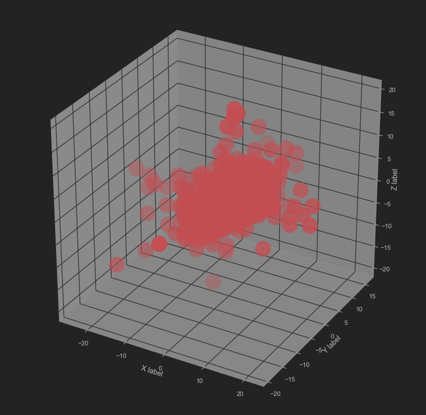

```python
fig = plt.figure(figsize = (15, 15))
ax = fig.add_subplot(111, projection = '3d')
#ax.set_proj_type('ortho')

x = daily_return_df['TWTR'].tolist()
y = daily_return_df['FB'].tolist()
z = daily_return_df['NFLX'].tolist()

ax.scatter(x, y, z, c = 'r', s = 1000)
ax.set_xlabel('X label')
ax.set_ylabel('Y label')
ax.set_zlabel('Z label')
```